# Webscraping example no.3

Fernando Hernández Esquivel

21 de mayo de 2019

El siguiente ejemplo se relizó sobre las medallistas olímpicas de Tae Kwondo que han participado desde Sydney en el año 2000 hasta los juegos olímpicos de Río de Janeiro de 2016, se tomó la categoria de 49-57 Kg, con lo que se pretende obtener información relevante sobre este deporte a través de la información mostrada en la página oficial de los juegos olímpicos. Para ir a la página presiona en el siguiente [enlace](https://www.olympic.org/taekwondo/49-57-kg-women)

Se cargan las librerías

```r
library(dplyr)
library(tidyverse)
library(syuzhet)
library(rvest)
library(stringr)
library(XML)
```

Se comienza por crear las tablas por año

2016

```r
t2016<-read_html(x="https://www.olympic.org/rio-2016/taekwondo/49-57-kg-women")
# nombres
name16<-t2016%>%
  html_nodes(css=".name , .th-row .col2")%>%
  html_text()
name16<-name16[63:78]
name16
```

```
##  [1] "Jade JONES"                   "Eva CALVO GOMEZ"
##  [3] "Hedaya WAHBA"                 "Kimia ALIZADEH ZENOORIN"
##  [5] "Nikita GLASNOVIC"             "Raheleh ASEMANI"
##  [7] "Naima BAKKAL"                 "Phannapa HARNSUJIN"
##  [9] "Mayu HAMADA"                  "Suvi MIKKONEN"
## [11] "Doris PATINO"                 "Rahma BEN ALI"
## [13] "Ana ZANINOVIC"                "Julia VASCONCELOS DOS SANTOS"
## [15] "Carolena CARSTENS"            "Caroline MARTON"
```

```r
# posiciones
place16<-t2016%>%
  html_nodes(css="td.col1")%>%
  html_text()
place16<-unlist(str_extract_all(place16,"[[:alpha:][:digit:]]{1,2}"))
place16
```

```
##  [1] "G"  "S"  "B"  "B"  "5"  "5"  "7"  "7"  "9"  "9"  "11" "11" "11" "11"
## [15] "11" "11"
```

```r
# país
country16<-t2016%>%
  html_nodes(css=".profile-row span , .th-row .col2")%>%
  html_text()
country16<-country16[2:17]
country16
```

```
##  [1] "GBR" "ESP" "EGY" "IRI" "SWE" "BEL" "MAR" "THA" "JPN" "FIN" "COL"
## [12] "TUN" "CRO" "BRA" "PAN" "AUS"
```

```r
# tabla
RIO_2016<-data.frame(Place=place16,Name=name16,Country=country16)
RIO_2016
```

```
##    Place                         Name Country
## 1      G                   Jade JONES     GBR
## 2      S              Eva CALVO GOMEZ     ESP
## 3      B                 Hedaya WAHBA     EGY
## 4      B      Kimia ALIZADEH ZENOORIN     IRI
## 5      5             Nikita GLASNOVIC     SWE
## 6      5              Raheleh ASEMANI     BEL
## 7      7                 Naima BAKKAL     MAR
## 8      7           Phannapa HARNSUJIN     THA
## 9      9                  Mayu HAMADA     JPN
## 10     9                Suvi MIKKONEN     FIN
## 11    11                 Doris PATINO     COL
## 12    11                Rahma BEN ALI     TUN
## 13    11                Ana ZANINOVIC     CRO
## 14    11 Julia VASCONCELOS DOS SANTOS     BRA
## 15    11            Carolena CARSTENS     PAN
## 16    11              Caroline MARTON     AUS
```

2012

```r
t2012<-read_html(x="https://www.olympic.org/london-2012/taekwondo/49-57-kg-women")
# nombre
name12<-t2012%>%
  html_nodes(css=".name")%>%
  html_text()
name12<-name12[62:99]
name12<-str_trim(name12,side="both")
name12<-unique(name12)
name12
```

```
##  [1] "Li-Cheng TSENG"        "Rangsiya NISAISOM"
##  [3] "Andrea PAOLI"          "Nidia MUNOZ"
##  [5] "Mayu HAMADA"           "Ana ZANINOVIC"
##  [7] "Jade JONES"            "Dragana GLADOVIC"
##  [9] "Hedaya WAHBA"          "Robin CHEONG"
## [11] "Marlene HARNOIS"       "Yeny CONTRERAS LOYOLA"
## [13] "Suvi MIKKONEN"         "Bineta DIEDHIOU"
## [15] "Yuzhuo HOU"            "Diana LOPEZ"
```

```r
# país
country12<-t2012%>%
  html_nodes(css=".profile-row span")%>%
  html_text()
country12<-unique(country12)
country12
```

```
##  [1] "TPE" "THA" "LBN" "CUB" "JPN" "CRO" "GBR" "SRB" "EGY" "NZL" "FRA"
## [12] "CHI" "FIN" "SEN" "CHN" "USA"
```

```r
# tabla
LONDON_2012<-data.frame(Place=place16,Name=name12,Country=country12)
LONDON_2012$Place[LONDON_2012$Country=="GBR"]="G"
LONDON_2012$Place[LONDON_2012$Country=="CHN"]="S"
LONDON_2012$Place[LONDON_2012$Country=="TPE"]="B"
LONDON_2012$Place[LONDON_2012$Country=="FRA"]="B"
LONDON_2012$Place[LONDON_2012$Country=="JPN"]="5"
LONDON_2012$Place[LONDON_2012$Country=="FIN"]="5"
LONDON_2012$Place[LONDON_2012$Country=="LBN"]="5"
LONDON_2012$Place[LONDON_2012$Country=="EGY"]="5"
LONDON_2012$Place[LONDON_2012$Country=="CUB"]="7"
LONDON_2012$Place[LONDON_2012$Country=="CRO"]="7"
LONDON_2012$Place[LONDON_2012$Country=="NZL"]="7"
LONDON_2012$Place[LONDON_2012$Country=="CHI"]="7"
LONDON_2012$Place[LONDON_2012$Country=="SEN"]="7"
LONDON_2012$Place[LONDON_2012$Country=="THA"]="7"
LONDON_2012$Place[LONDON_2012$Country=="SRB"]="7"
LONDON_2012$Place[LONDON_2012$Country=="USA"]="7"
LONDON_2012
```

```
##    Place                  Name Country
## 1      B        Li-Cheng TSENG     TPE
## 2      7     Rangsiya NISAISOM     THA
## 3      5          Andrea PAOLI     LBN
## 4      7           Nidia MUNOZ     CUB
## 5      5           Mayu HAMADA     JPN
## 6      7         Ana ZANINOVIC     CRO
## 7      G            Jade JONES     GBR
## 8      7      Dragana GLADOVIC     SRB
## 9      5          Hedaya WAHBA     EGY
## 10     7          Robin CHEONG     NZL
## 11     B       Marlene HARNOIS     FRA
## 12     7 Yeny CONTRERAS LOYOLA     CHI
## 13     5         Suvi MIKKONEN     FIN
## 14     7       Bineta DIEDHIOU     SEN
## 15     S            Yuzhuo HOU     CHN
## 16     7           Diana LOPEZ     USA
```

2008

```r
t2008<-read_html(x="https://www.olympic.org/beijing-2008/taekwondo/49-57-kg-women")
# nombre
name8<-t2008%>%
  html_nodes(css=".name")%>%
  html_text()
name8<-name8[62:101]
name8<-str_trim(name8,side = "both")
name8<-unique(name8)
name8
```

```
##  [1] "Robin CHEONG"           "Mariam BAH"
##  [3] "Sujeong LIM"            "Li-Wen SU"
##  [5] "Veronica CALABRESE"     "Doris PATINO"
##  [7] "Bineta DIEDHIOU"        "Thi Hoai Thu NGUYEN"
##  [9] "Diana LOPEZ"            "Chonnapas PREMWAEW"
## [11] "Azize TANRIKULU"        "Elaine Shueh Fhern TEO"
## [13] "Martina ZUBCIC"         "Bat-El GATTERER"
## [15] "Debora NUNES"           "Lailatou AMADOU LELE"
```

```r
# país
country8<-t2008%>%
  html_nodes(css=".profile-row")%>%
  html_text()
country8<-unlist(str_extract_all(country8,"[[:alpha:]]{3}"))
country8<-unique(country8)
country8
```

```
##  [1] "NZL" "CIV" "KOR" "TPE" "ITA" "COL" "SEN" "VIE" "USA" "THA" "TUR"
## [12] "MAS" "CRO" "ISR" "BRA" "NIG"
```

```r
# tabla
BEIJING_2008<-data.frame(Place=place16,Name=name8,Country=country8)
BEIJING_2008$Place[BEIJING_2008$Name=="Sujeong LIM"]="G"
BEIJING_2008$Place[BEIJING_2008$Name=="Azize TANRIKULU"]="S"
BEIJING_2008$Place[BEIJING_2008$Name=="Diana LOPEZ"]="B"
BEIJING_2008$Place[BEIJING_2008$Name=="Martina ZUBCIC"]="B"
BEIJING_2008$Place[BEIJING_2008$Country==c("NZL")]="5"
BEIJING_2008$Place[BEIJING_2008$Country==c("SEN")]="5"
BEIJING_2008$Place[BEIJING_2008$Country==c("USA")]="5"
BEIJING_2008$Place[BEIJING_2008$Country==c("BRA")]="5"
BEIJING_2008$Place[BEIJING_2008$Country==c("CIV")]="7"
BEIJING_2008$Place[BEIJING_2008$Country==c("TPE")]="7"
BEIJING_2008$Place[BEIJING_2008$Country==c("COL")]="7"
BEIJING_2008$Place[BEIJING_2008$Country==c("VIE")]="7"
BEIJING_2008$Place[BEIJING_2008$Country==c("THA")]="7"
BEIJING_2008$Place[BEIJING_2008$Country==c("MAS")]="7"
BEIJING_2008$Place[BEIJING_2008$Country==c("ISR")]="7"
BEIJING_2008$Place[BEIJING_2008$Country==c("NIG")]="7"
BEIJING_2008
```

```
##    Place                   Name Country
## 1      5           Robin CHEONG     NZL
## 2      7             Mariam BAH     CIV
## 3      G            Sujeong LIM     KOR
## 4      7              Li-Wen SU     TPE
## 5      5     Veronica CALABRESE     ITA
## 6      7           Doris PATINO     COL
## 7      5        Bineta DIEDHIOU     SEN
## 8      7    Thi Hoai Thu NGUYEN     VIE
## 9      5            Diana LOPEZ     USA
## 10     7     Chonnapas PREMWAEW     THA
## 11     S        Azize TANRIKULU     TUR
## 12     7 Elaine Shueh Fhern TEO     MAS
## 13     B         Martina ZUBCIC     CRO
## 14     7        Bat-El GATTERER     ISR
## 15     5           Debora NUNES     BRA
## 16     7   Lailatou AMADOU LELE     NIG
```

2004

```r
t2004<-read_html(x="https://www.olympic.org/athens-2004/taekwondo/49-57-kg-women")
# nombre
name4<-t2004%>%
  html_nodes(css=".name")%>%
  html_text()
name4<-name4[62]
name4
```

```
## [1] "Iridia SALAZAR BLANCO"
```

```r
# país
country4<-t2004%>%
  html_nodes(css="span")%>%
  html_text()
country4<-country4[50]
country4
```

```
## [1] "MEX"
```

```r
# tabla
ATHENS_2004<-data.frame(Place=place16[3],Name=name4,Country=country4)
ATHENS_2004<-ATHENS_2004%>%add_row(Place="S",Name="Nia ABDALLAH",Country="USA")
ATHENS_2004<-ATHENS_2004%>%add_row(Place="G",Name="Ji Won JANG",Country="KOR")
ATHENS_2004
```

```
##   Place                  Name Country
## 1     B Iridia SALAZAR BLANCO     MEX
## 2     S          Nia ABDALLAH     USA
## 3     G           Ji Won JANG     KOR
```

2000

```r
t2000<-read_html(x="https://www.olympic.org/sydney-2000/taekwondo/49-57-kg-women")
# nombre
name0<-t2000%>%
  html_nodes(css=".name")%>%
  html_text()
name0<-name0[62:73]
name0
```

```
##  [1] "Jae-Eun JUNG"         "Hieu Ngan TRAN"       "Hamide BIKCIN"
##  [4] "Virginia LOURENS"     "Cristiana CORSI"      "Jasmin STRACHAN"
##  [7] "Cheryl-Ann SANKAR"    "Areti ATHANASOPOULOU" "Chih-Ling HSU"
## [10] "Shimaa AFIFI"         "Carmen SILVA"         "Cynthia CAMERON"
```

```r
# posiciones
place0<-t2000%>%
  html_nodes(css="td.col1")%>%
  html_text()
place0<-unlist(str_extract_all(place0,"[[:alpha:][:digit:]]{1,2}"))
place0
```

```
##  [1] "G"  "S"  "B"  "4"  "5"  "5"  "7"  "8"  "8"  "10" "10" "10"
```

```r
# país
country0<-t2000%>%
  html_nodes(css=".profile-row span")%>%
  html_text()
country0
```

```
##  [1] "KOR" "VIE" "TUR" "NED" "ITA" "PHI" "TRI" "GRE" "TPE" "EGY" "BRA"
## [12] "AUS"
```

```r
# tabla
SIDNEY_2000<-data.frame(Place=place0,Name=name0,Country=country0)
SIDNEY_2000
```

```
##    Place                 Name Country
## 1      G         Jae-Eun JUNG     KOR
## 2      S       Hieu Ngan TRAN     VIE
## 3      B        Hamide BIKCIN     TUR
## 4      4     Virginia LOURENS     NED
## 5      5      Cristiana CORSI     ITA
## 6      5      Jasmin STRACHAN     PHI
## 7      7    Cheryl-Ann SANKAR     TRI
## 8      8 Areti ATHANASOPOULOU     GRE
## 9      8        Chih-Ling HSU     TPE
## 10    10         Shimaa AFIFI     EGY
## 11    10         Carmen SILVA     BRA
## 12    10      Cynthia CAMERON     AUS
```

Se crea una tabla general, con todas las atletas

```r
S<-SIDNEY_2000
A<-ATHENS_2004
B<-BEIJING_2008
L<-LONDON_2012
R<-RIO_2016
tg<-rbind(S,A,B,L,R)
tg
```

```
##    Place                         Name Country
## 1      G                 Jae-Eun JUNG     KOR
## 2      S               Hieu Ngan TRAN     VIE
## 3      B                Hamide BIKCIN     TUR
## 4      4             Virginia LOURENS     NED
## 5      5              Cristiana CORSI     ITA
## 6      5              Jasmin STRACHAN     PHI
## 7      7            Cheryl-Ann SANKAR     TRI
## 8      8         Areti ATHANASOPOULOU     GRE
## 9      8                Chih-Ling HSU     TPE
## 10    10                 Shimaa AFIFI     EGY
## 11    10                 Carmen SILVA     BRA
## 12    10              Cynthia CAMERON     AUS
## 13     B        Iridia SALAZAR BLANCO     MEX
## 14     S                 Nia ABDALLAH     USA
```

[output cut: 49 more lines]

Se divide la tabla por categoría de medalla

```r
# oro
gt<-subset(tg,subset =Place=="G")
# plata
st<-subset(tg,subset =Place=="S")
# bronce
bt<-subset(tg,subset =Place=="B")
# tabla
tf<-rbind(gt,st,bt)
tf<-data.frame(tf)
tf
```

```
##    Place                    Name Country
## 1      G            Jae-Eun JUNG     KOR
## 15     G             Ji Won JANG     KOR
## 18     G             Sujeong LIM     KOR
## 38     G              Jade JONES     GBR
## 48     G              Jade JONES     GBR
## 2      S          Hieu Ngan TRAN     VIE
## 14     S            Nia ABDALLAH     USA
## 26     S         Azize TANRIKULU     TUR
## 46     S              Yuzhuo HOU     CHN
## 49     S         Eva CALVO GOMEZ     ESP
## 3      B           Hamide BIKCIN     TUR
## 13     B   Iridia SALAZAR BLANCO     MEX
## 28     B          Martina ZUBCIC     CRO
## 32     B          Li-Cheng TSENG     TPE
## 42     B         Marlene HARNOIS     FRA
## 50     B            Hedaya WAHBA     EGY
## 51     B Kimia ALIZADEH ZENOORIN     IRI
```

De la tabla anterior se observa que la única atleta en ganar 2 medallas es Jade Jones

Ahora se grafica por total de país

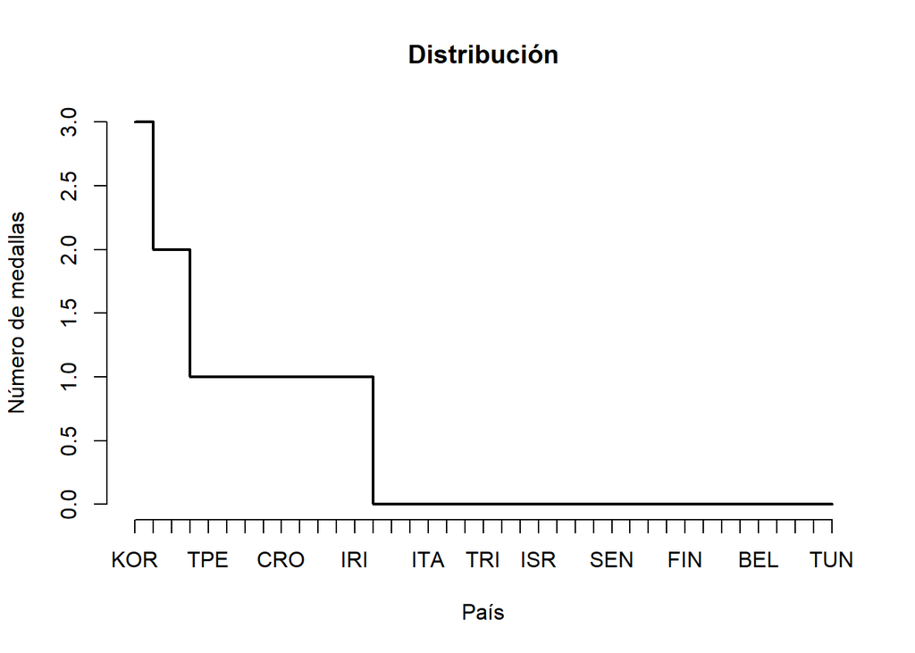

```r
plot(sort(table(tf$Country),decreasing = TRUE),
     ylab = "Número de medallas",xlab = "País",
     main="Distribución",type = "s")
```

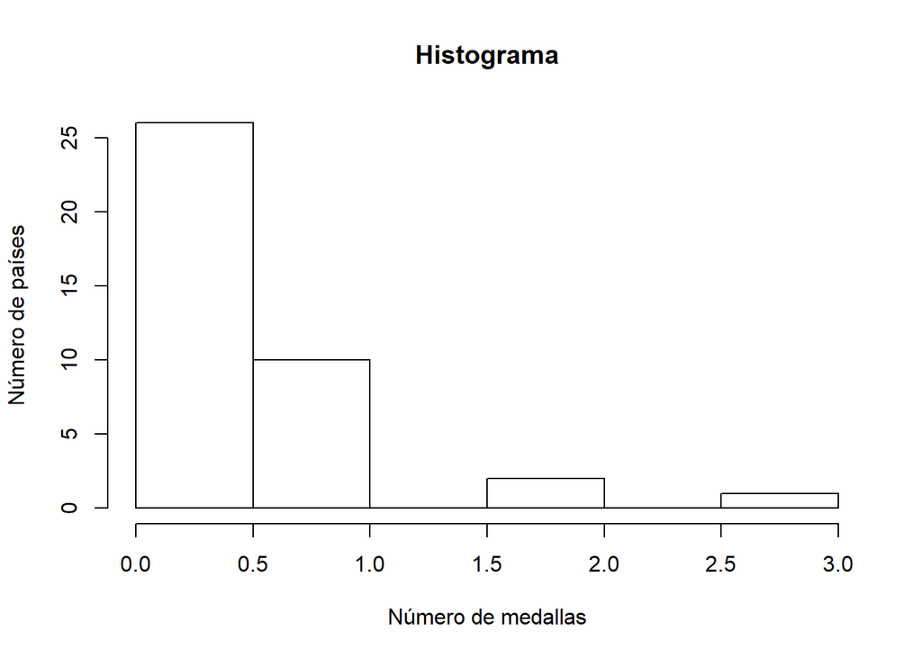

```r
hist(sort(table(tf$Country),decreasing = TRUE),
     xlab = "Número de medallas",ylab = "Número de países",
     main="Histograma")
```

```r
sort(table(tf$Country),decreasing = TRUE)
```

```
##
## KOR TUR GBR EGY TPE VIE MEX USA CRO CHN FRA ESP IRI AUS BRA GRE ITA NED
##   3   2   2   1   1   1   1   1   1   1   1   1   1   0   0   0   0   0
## PHI TRI CIV COL ISR MAS NIG NZL SEN THA CHI CUB FIN JPN LBN SRB BEL MAR
##   0   0   0   0   0   0   0   0   0   0   0   0   0   0   0   0   0   0
## PAN SWE TUN
##   0   0   0
```

```r
length(unique(tg$Country))
```

```
## [1] 39
```

```r
length(unique(tf$Country))
```

```
## [1] 13
```

Finalmente, se grafica por categoría

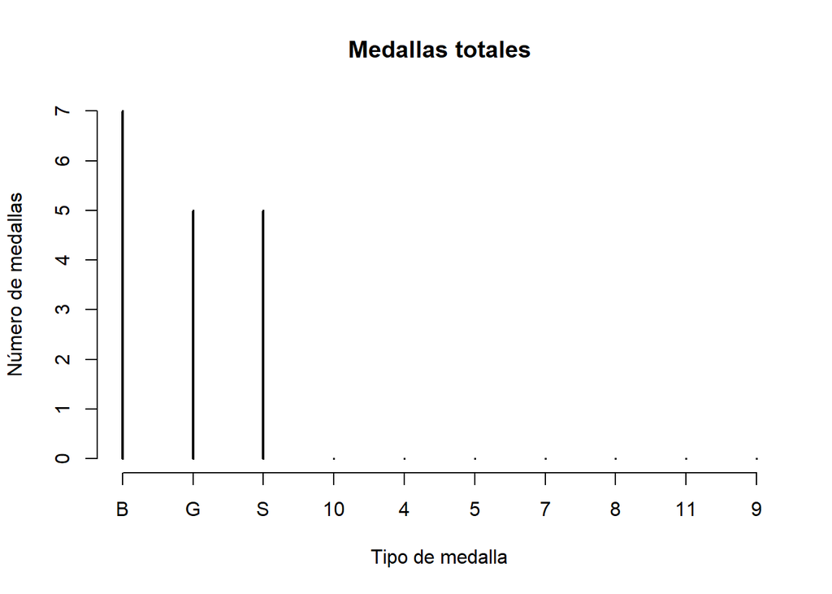

```r
plot(sort(table(tf$Place),decreasing = TRUE),
     ylab = "Número de medallas",xlab = "Tipo de medalla",
     main="Medallas totales")
```

```r
sort(table(tf$Place),decreasing = TRUE)
```

```
##
##  B  G  S 10  4  5  7  8 11  9
##  7  5  5  0  0  0  0  0  0  0
```

El número total de medallas entregadas desde el año 2000 hasta el año 2016 fue de 17 medallas, con una distribución de 5 de oro, 5 de plata y 7 de bronce.